# Tank bromeliad habitat features serve as predictors of invertebrate abundance and richness

Theresa (Tess Konnovitch), Gonzalez Lab, RUC - CCIB 4/29/2021

## Introduction

Invertebrates are responsible for a plethora of important ecosystem services, such as decomposition, water filtration, nutrient cycling, disease mitigation, and more (Lavaelle et al., 2006). Given these invaluable services, the recently observed patterns of invertebrate community and population declines in abundance and richness are causing concern and an increased number of investigations in the scientific community. Classical ecological patterns suggest that invertebrate diversity and abundance are positively correlated with habitat size, although studies have reported system-dependent results (Joque & Field, 2014). Tank bromeliads (Bromeliaceae) provide a unique type of habitat to many invertebrates in the neotropics. Tank bromeliad leaves hold freshwater, creating a microecosystem for invertebrates and an ideal model system for environmental manipulation experiments, due to size and tractability (Srivastava et al., 2004). Using invertebrate response data collected in Brazil, I ran a statistical analysis on three habitat variables (number of leaves, plant area, and maximum volume of water the plant holds) to investigate the relationship between tank bromeliad structure and invertebrate response. Using generalized linear models, I found that these features can predict invertebrate richness and abundance, further supporting the theory that habitat can predict invertebrate community assembly. This study also provides invaluable insight as I prepare for a similar experiment in Brazil.

## Data

This data was collected by Mark Nessel, along with other members and colleagues of the Gonzalez Lab, in 2019 along the coast of Brazil. Invertebrate communities from 12 plants at each of the 10 sites were analyzed.

The data frame (pd) contains a row for each plant in the survey. The following are descriptions for the columns referenced in this project:

- `plant_area`: The area of plant, calculated using multiple diameter measurements.
- `Leaves`: Total number of leaves on the plant
- `Max.volume`: Maximum volume in plant
- `id`: refernce ID for the project, created using site name + plant number (e.g., Cardoso1 refers to plant 1 from Cardoso). There are 12 plants from each of the 10 sites.
- `inv_abundance`: number of individual invertebrates per plant
- `n_species`: number of unique morphospecies per plant

```r
setwd("C:/Users/tessa/OneDrive/Documents/Classes/AEDA/konnovitch_theresa")
pd <- read.csv("Survey_Plant_Data.csv")
```

## Methods

My methods consist of five steps: plotting to visualize the data, running statistics, checking assumptions, interpreting the results, and plotting the model back on the data picture.

### Step 1: Plot the Data

I started by plotting variables to “eyeball” the data. I plotted all combinations of variables (e.g., explanatory vs. response, response vs. response, explanatory vs. explanatory) as a data exploration exercise.

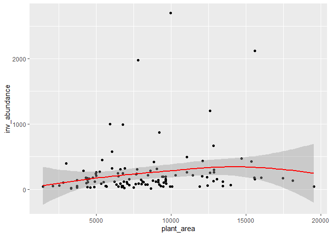

```r
#plant area and abundance
ggplot(pd, aes(x = plant_area, y = inv_abundance))+
    geom_point()+
    geom_smooth(span = 1, color = "red", method = "loess")
```

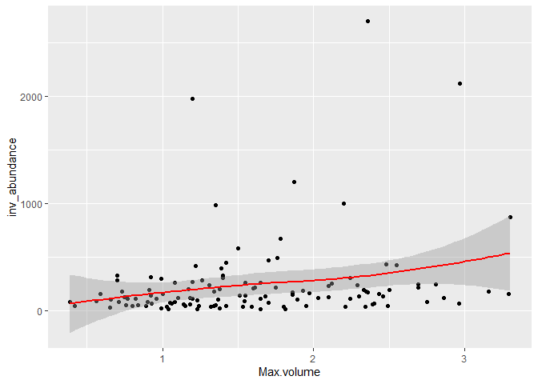

```r
#max volume and abundance
ggplot(pd, aes(x = Max.volume, y = inv_abundance))+
    geom_point()+
    geom_smooth(span = 1, color = "red", method = "loess")
```

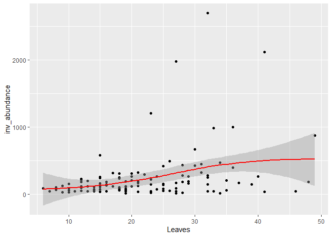

```r
#leaves and abundance
ggplot(pd, aes(x = Leaves, y = inv_abundance))+
    geom_point()+
    geom_smooth(span = 1, color = "red", method = "loess")
```

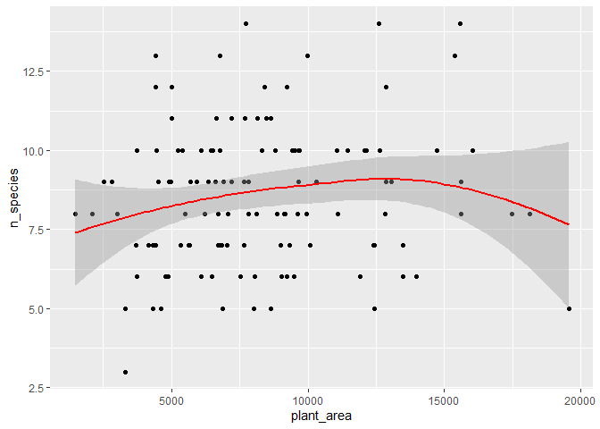

```r
#plant area and richness
ggplot(pd, aes(x = plant_area, y = n_species))+
    geom_point()+
    geom_smooth(span = 1, color = "red", method = "loess")
```

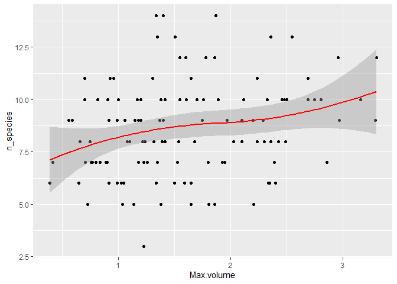

```r
#max volume and richness
ggplot(pd, aes(x = Max.volume, y = n_species))+
    geom_point()+
    geom_smooth(span = 1, color = "red", method = "loess")
```

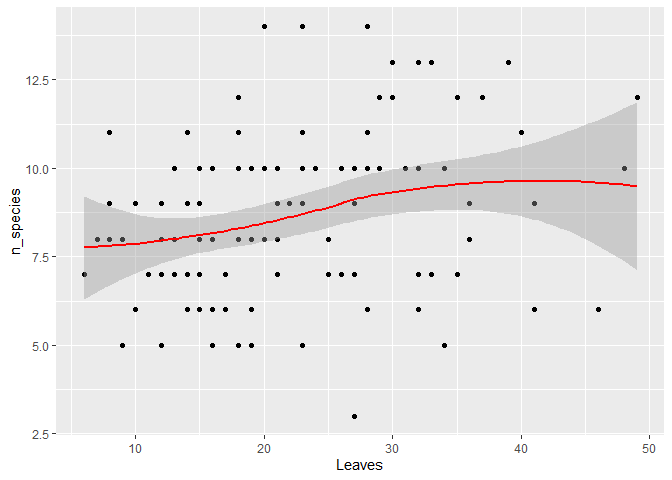

```r
#leaves and richness
ggplot(pd, aes(x = Leaves, y = n_species))+
    geom_point()+
    geom_smooth(span = 1, color = "red", method = "loess")
```

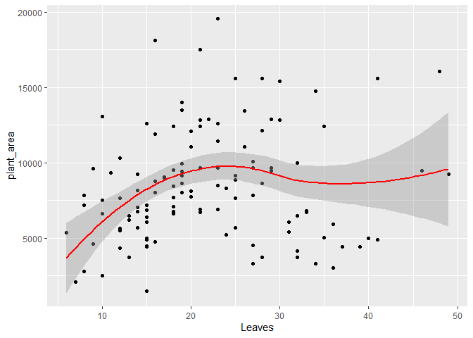

```r
#leaves and plant area
ggplot(pd, aes(x = Leaves, y = plant_area))+
    geom_point()+
    geom_smooth(span = 1, color = "red", method = "loess")
```

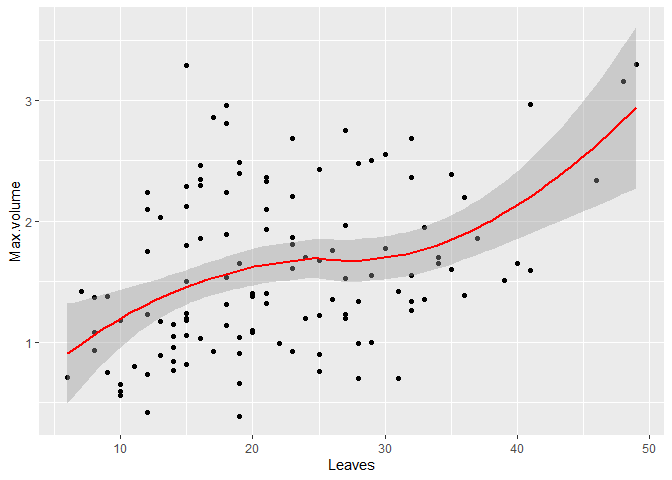

```r
#leaves and max volume
ggplot(pd, aes(x = Leaves, y = Max.volume))+
    geom_point()+
    geom_smooth(span = 1, color = "red", method = "loess")
```

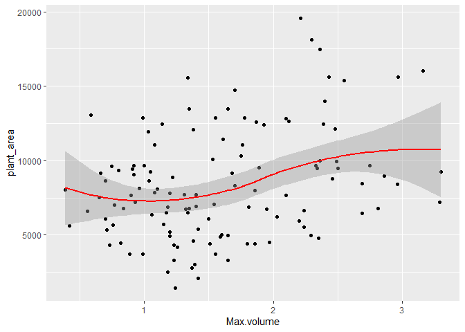

```r
#ax volume and plant area
ggplot(pd, aes(x = Max.volume, y = plant_area))+
    geom_point()+
    geom_smooth(span = 1, color = "red", method = "loess")
```

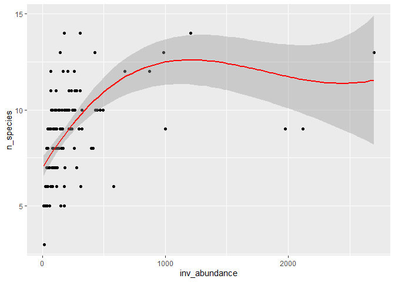

```r
#richness and abundance
ggplot(pd, aes(x = inv_abundance, y = n_species))+
    geom_point()+
    geom_smooth(span = 1, color = "red", method = "loess")
```